# template_main_qc

Alyna Khan

January 26, 2024

# Main Document

## General QC checks

This document performs quality control checks on all cmqt data sets.

```
## [1] "gs://fc-e3b6ff37-761e-4e53-89c0-fb243b8bd8e5/cmqt_lipids.tsv"
```

QC check for general variables

| Variable | Min Value | Max Value | Pass QC | Fail QC Min | Fail QC Max | Null Values |
| --- | --- | --- | --- | --- | --- | --- |
| age_at_obs | 0 | 90 | 20 | 0 | 0 | 0 |

### CMQT Lipids QC

This document performs quality control checks on the cmqt_lipids data sets. Specific checks are determined through a collaborative effort between the CMQT sub-working group, the Phenotype Harmonization Working Group, and the CC.

QC check for lipids variables

| Variable | Min Value | Max Value | Pass QC | Fail QC Min | Fail QC Max | Null Values |
| --- | --- | --- | --- | --- | --- | --- |
| triglycerides_1 | 238.5923 | 994.137 | 20 | 0 | 0 | 0 |

## General QC checks

This document performs quality control checks on all cmqt data sets.

```
## [1] "gs://fc-e3b6ff37-761e-4e53-89c0-fb243b8bd8e5/cmqt_blood_pressure.tsv"
```

QC check for general variables

| Variable | Min Value | Max Value | Pass QC | Fail QC Min | Fail QC Max | Null Values |
| --- | --- | --- | --- | --- | --- | --- |
| age_at_obs | 0 | 90 | 20 | 0 | 0 | 0 |

### CMQT Blood Pressure QC

This document performs quality control checks on the cmqt_blood_pressure data sets. Specific checks are determined through a collaborative effort between the CMQT sub-working group, the Phenotype Harmonization Working Group, and the CC.

QC check for blood pressure variables

| Variable | Min Value | Max Value | Pass QC | Fail QC Min | Fail QC Max | Null Values |
| --- | --- | --- | --- | --- | --- | --- |
| systolic_bp_1 | -219.7946 | 348.3547 | 20 | 0 | 0 | 0 |
| diastolic_bp_1 | -319.3527 | 516.4990 | 20 | 0 | 0 | 0 |
| bp_consistency | NA | NA | 8 | 12 | NA | 0 |

## General QC checks

This document performs quality control checks on all cmqt data sets.

```
## [1] "gs://fc-e3b6ff37-761e-4e53-89c0-fb243b8bd8e5/cmqt_anthropometry.tsv"
```

QC check for general variables

| Variable | Min Value | Max Value | Pass QC | Fail QC Min | Fail QC Max | Null Values |
| --- | --- | --- | --- | --- | --- | --- |
| age_at_obs | 0 | 90 | 20 | 0 | 0 | 0 |

### CMQT Anthropometry QC

This document performs quality control checks on the cmqt_anthropometry data sets. Specific checks are determined through a collaborative effort between the CMQT sub-working group, the Phenotype Harmonization Working Group, and the CC.

QC check for anthropometry variables

| Variable | Min Value | Max Value | Pass QC | Fail QC Min | Fail QC Max | Null Values |
| --- | --- | --- | --- | --- | --- | --- |
| height_1 | 477.02056 | 531.92976 | 20 | 0 | 0 | 0 |
| weight_1 | 380.02294 | 418.53963 | 20 | 0 | 0 | 0 |
| bmi_1 | 13.78584 | 17.60961 | 20 | 0 | 0 | 0 |
| bmi_consistency | NA | NA | 14 | NA | NA | 0 |

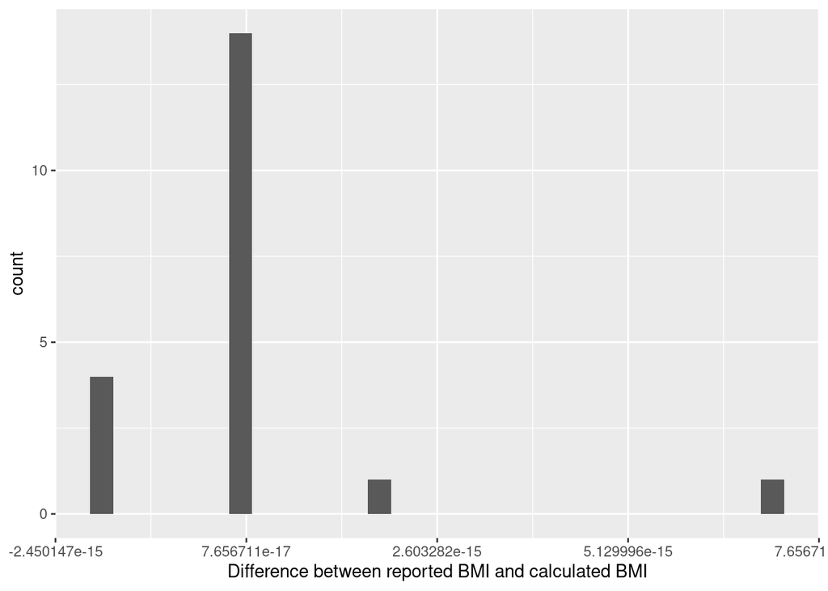

## General QC checks

This document performs quality control checks on all cmqt data sets.

```
## [1] "gs://fc-e3b6ff37-761e-4e53-89c0-fb243b8bd8e5/cmqt_hematology.tsv"
```

QC check for general variables

| Variable | Min Value | Max Value | Pass QC | Fail QC Min | Fail QC Max | Null Values |
| --- | --- | --- | --- | --- | --- | --- |
| age_at_obs | 0 | 90 | 20 | 0 | 0 | 0 |

### CMQT Hematology QC

This document performs quality control checks on the cmqt_hematology data sets. Specific checks are determined through a collaborative effort between the CMQT sub-working group, the Phenotype Harmonization Working Group, and the CC.

QC check for hematology variables

| Variable | Min Value | Max Value | Pass QC | Fail QC Min | Fail QC Max | Null Values |
| --- | --- | --- | --- | --- | --- | --- |
| wbc_1 | -367.676803 | 561.469876 | 20 | 0 | 0 | 0 |
| hemoglobin_1 | -74.945698 | 89.188497 | 20 | 0 | 0 | 0 |
| hematocrit_1 | -1.373967 | 2.108672 | 20 | 0 | 0 | 0 |
| platelet_count_1 | 72.841399 | 1551.624934 | 20 | 0 | 0 | 0 |